# mpoly: Multivariate Polynomials in R

# Evaluating polynomials

Apart from being interesting algebraic objects, polynomials can of course be thought of as functions. To access this functional perspective, we can convert an `"mpoly"` or `"mpolyList"` object to a `function` using the `"mpoly"` method of `as.function`. This is particularly suited to R’s strengths since R is geared towards evaluation and numerical optimization

```r
> library("ggplot2"); theme_set(theme_bw())
> ( p <- mp("x") * mp("x - .5") * mp("x -  1") ) # x(x-.5)(x-1)
x^3  -  1.5 x^2  +  0.5 x
> f <- as.function(p)
f(x)
> f
function(x){x**3  -  1.5 * x**2  +  0.5 * x}
<environment: 0x1218bc270>
> f(10)
[1] 855
> s <- seq(-.1, 1.1, length.out = 201)
> df <- data.frame(x = s, y = f(s))
> qplot(x, y, data = df, geom = "path") + geom_hline(yintercept = 0, colour = I("red"))
```

The plot generated is included in Figure 1, where one can see that the function has the correct zeros.

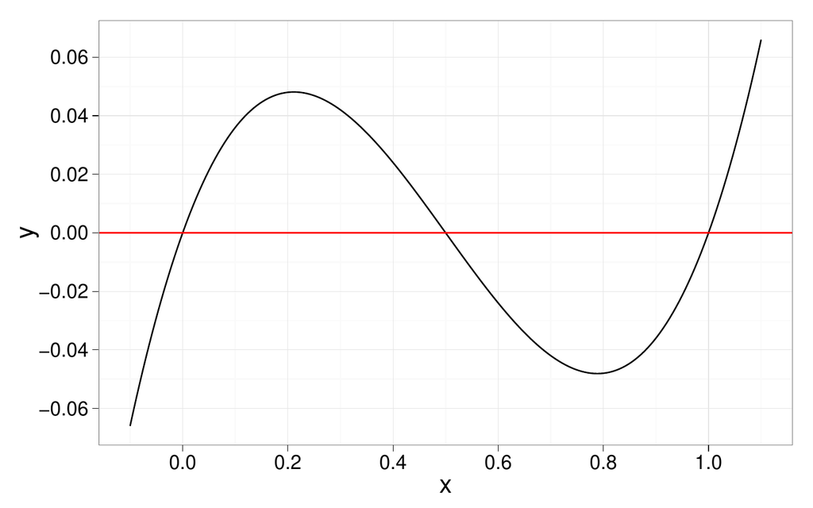

Figure 1: The as.function method for "mpoly" objects.

For multivariate polynomials the syntax is the same, and `as.function` can provide the function with (1) a vector argument (ideal for passing to optimization routines such as `optim`) or (2) a sequence of arguments.

```r
> mpoly <- mp("x + 3 x y + z^2 x")
>
> f <- as.function(mpoly)
f(.) with . = (x, y, z)
> f(1:3)
[1] 16
>
> f <- as.function(mpoly, vector = FALSE)
f(x, y, z)
> f(1, 2, 3)
[1] 16
```

`"mpolyList"` objects can be converted into functions in the same way. Note that in both cases the user is messaged with the appropriate syntax for the resulting function.

```r
> polys <- mp(c("x + 1", "y^2 + z"))
> f <- as.function(polys)
f(.) with . = (x, y, z)
> f(1:3)
[1] 2 7
```

Another neat example for illustrating this is visualizing Rosenbrock’s "banana" function,
$$f(x,y) =
(1-x)^2 + 100(y-x^2)^2,$$
which is a common test example for optimization routines (Figure 2).

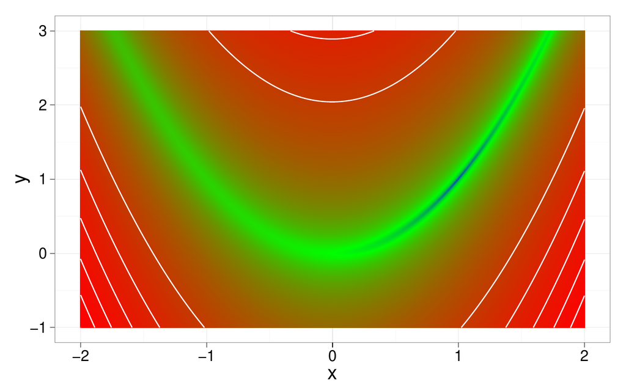

Figure 2: The Rosenbrock function plotted by evaluating an "mpoly" object via as.function and apply with vector arguments.

```r
> f <- mp("1 - 2 x + x^2 + 100 x^4 - 200 x^2 y + 100 y^2")
> f <- as.function(f)
> df <- expand.grid(x = seq(-2, 2, .01), y = seq(-1, 3, .01))
> df$f <- apply(df, 1, f)
> library("scales")
> qplot(x, y, data = df, geom = c("raster", "contour"),
+    fill = f + .001, z = f, colour = I("white"), bins = 6) +
+  scale_fill_gradient2(
+    low = "blue", mid = "green", high = "red",
+    trans = "log10", guide = "none"
+  )
```

# Conclusion and future directions

While other functionality is also provided (such as a `terms` method, a function to compute least common multiples, and some combinatorial functions), the presented ones are the main contributions of the *mpoly* package. Put together, they provide a package which is not only user-friendly, efficient, and useful for polynomial algebra, but also a solid foundation upon which further developments can be made to make polynomials more accessible in R. In particular, it provides a nice starting point for any future package dealing with algebraic statistics.

There are, however, several improvements which can be made. First, the primary constructor function `mpoly` can be made significantly faster by outsourcing its job to C++, as previously suggested (Hankin 2008). Second, improvements can be made to speed up some of the arithmetic, for example addition-chain exponentiation for polynomial exponents (as opposed to iterative multiplication). Last, improvements can be made into the flexibility of the facilitated constructor `mp`. In particular, parenthetical expressions are not currently handled but would be of great practical use.

# Acknowledgments

The author would like to thank Martyn Plummer and two anonymous reviewers for useful suggestions which made this and future work better.

Diaconis, P., and B. Sturmfels. 1998. “Algebraic Algorithms for Sampling from Conditional Distributions.” *The Annals of Statistics* 26 (1): 363–97.

Drton, M., B. Sturmfels, and S. Sullivant. 2009. *Lectures on Algebraic Statistics*. Birkhäuser.

Grothendieck, G., and C. J. G. Bellosta. 2010. *rSymPy: R Interface to SymPy Computer Algebra System*. http://CRAN.R-project.org/package=rSymPy.

Hankin, R. K. S. 2008. “Programmers’ Niche: Multivariate Polynomials in R.” *R News* 8 (1): 41–45.

———. 2010. *Multipol: Multivariate Polynomials*. http://CRAN.R-project.org/package=multipol.

Kahle, David. 2012. *Mpoly: Symbolic Computation and More with Multivariate Polynomials*. http://CRAN.R-project.org/package=mpoly.

Maplesoft. 2012. *Maple 16*. Waterloo, Canada. http://www.maplesoft.com/.

Venables, B. 2010. *PolynomF: Polynomials in R,* . R package version 0.94. http://CRAN.R-project.org/package=PolynomF.

Venables, B., K. Hornik, and M. Maechler. 2009. *Polynom: A Collection of Functions to Implement a Class for Univariate Polynomial Manipulations*. http://CRAN.R-project.org/package=polynom.

Wolfram Research. 2012. *Mathematica 9.0*. Champaign. http://www.wolfram.com/.

[^1]: To be clear, this is in the `unique(names(unlist(mpoly)))` sense; the order of the terms matters when determining the intrinsic order.
[^2]: This is a subtle point. It is very possible that a polynomial in the ring $R[x,y]$ is coded with the intrinsic order $y > x$ and that, as a consequence, the typical lexicographic order will not be the one intended. The messaging is used to make clear what order is being used.
[^3]: `deriv` does not call the default method from *stats*.
[^4]: Buchberger’s algorithm is the standard method of calculating bases, however, faster methods are known.